# Análisis de índices académicos UMC 2019-02

*Hecho por [Samuel Ochoa](https://s8a.github.io), 21/02/2020*

La [UMC](http://www.umc.edu.ve) publicó los índices académicos acumulados (IAA) del período 2019-02 el 19 de febrero de 2020. Como desafío y práctica, decidí realizar este análisis estadístico de los índices académicos como una libreta interactiva de [Jupyter](https://jupyter.org/). El código utiliza [Python 3](https://www.python.org/) con las librerías [NumPy](https://numpy.org), [Matplotlib](https://matplotlib.org) y [Pandas](https://pandas.pydata.org).

Si no quiere leer todo el documento, puede saltar directamente a las conclusiones.

## Obtención y tratamiento de los datos

Los índices académicos fueron publicados como documentos PDF, disponibles en [este enlace](http://www.umc.edu.ve/index.php?option=com_content&view=article&layout=edit&id=376). No garantizo que el enlace funcione en un futuro. Debido a que los documentos PDF no están en un formato legible para máquinas, utilicé la herramienta [Tabula](https://tabula.technology/) para extraer las tablas de datos como archivos CSV y [LibreOffice Calc](https://www.libreoffice.org/discover/calc/) para cambiar los decimales a puntos en lugar de comas y corregir los errores de conversión (algunas letras en la columna del IAA).

Los archivos CSV resultantes están disponibles aquí:

- Licenciatura en Administración
- Ingeniería Ambiental
- Ingeniería Informática
- Ingeniería Marítima
- Licenciatura en Turismo

A continuación se muestra el código en Python para convertir estos archivos CSV a dataframes y series de Pandas para su posterior análisis estadístico:

```python
import matplotlib.pyplot as plt
import numpy as np
import pandas as pd

# Códigos y nombres de carreras
carreras = {
    'ADM': 'Licenciatura en Administración',
    'INGAMB': 'Ingeniería Ambiental',
    'INGINF': 'Ingeniería Informática',
    'INGM': 'Ingeniería Marítima',
    'TUR': 'Licenciatura en Turismo'
}

# Dataframes originales
dfs = {carrera: pd.read_csv('IAA_' + carrera + '.csv',
                            header = 0, index_col = 0)
       for carrera in carreras.keys()}

# Series de índices académicos solamente
iaa = {carrera: dfs[carrera]['IAA'] for carrera in carreras.keys()}

# Dataframe con los IAA de cada carrera
df_iaa = pd.DataFrame(iaa)
```

## Análisis general

Primero se hace una descripción estadística de la población estudiantil completa. A continuación se crea una función `describir_iaa` para describir brevemente una o varias series de índices académicos, y se aplica esta función a los IAA de la población estudiantil agrupados en una sola serie de datos:

```python
def contar_reg(serie):
    """Cantidad de estudiantes regulares en la serie de IAA"""
    return serie[serie >= 12].count()

def contar_pro(serie):
    """Cantidad de estudiantes en probatorio en la serie de IAA"""
    return serie[serie < 12].count()

def porcentaje_reg(serie):
    """Porcentaje de estudiantes regulares en la serie de IAA"""
    return contar_reg(serie)*100.0/serie.count()

def porcentaje_pro(serie):
    """Porcentaje de estudiantes en probatorio en la serie de IAA"""
    return contar_pro(serie)*100.0/serie.count()

def moda_max(serie):
    """Mayor valor de la moda de la serie de IAA"""
    return serie.mode().max()


def describir_iaa(df):
    """Descripción estadística de un dataframe con una
       o varias series de IAA."""
    return df.agg([
        # Cantidades: total, regulares, probatorio
        'count', contar_reg, contar_pro,
        # Porcentajes: regulares, probatorio
        porcentaje_reg, porcentaje_pro,
        # IAA máximo y minimo
        'max', 'min',
        # Medidas de tendencia central
        'mean', 'median', moda_max,
        # Medidas de dispersión
        'std', 'kurt', 'skew']).round(2)


def describir_carrera(carrera):
    """Descripción estadística de una sola carrera."""
    return describir_iaa(pd.DataFrame(df_iaa[carrera]))


# Serie con todos los IAA unidos
iaa_general = pd.DataFrame(pd.concat(iaa.values()))

# Descripción estadística
describir_iaa(iaa_general)
```

|  | IAA |
| --- | --- |
| count | 2910.00 |
| contar_reg | 2310.00 |
| contar_pro | 600.00 |
| porcentaje_reg | 79.38 |
| porcentaje_pro | 20.62 |
| max | 18.89 |
| min | 0.00 |
| mean | 13.31 |
| median | 13.92 |
| moda_max | 14.17 |
| std | 2.66 |
| kurt | 6.49 |
| skew | -2.09 |

La descripción estadística nos provee la siguiente información, en orden:

- La cantidad total de estudiantes.
- La cantidad y porcentaje de los estudiantes regulares y de los estudiantes en probatorio (IAA inferior a 12).
- El IAA más alto (18.89) y el más bajo (0.00).
- El [promedio](https://en.wikipedia.org/wiki/Mean) (13.31) es el valor al que tienden los índices académicos.
- La [mediana](https://en.wikipedia.org/wiki/Median) indica el valor central de la distribución, es decir, que el 50% de los IAA está por encima de 13.92 y el otro 50% está por debajo.
- La moda) es el valor más repetido en la distribución, es decir, que el IAA más común es de 14.17 puntos. Nótese que una distribución de frecuencia puede tener varias modas, porque es posible que haya dos valores que son los más repetidos; en este análisis siempre tomaremos el mayor valor de la moda.
- La [desviación estándar](https://en.wikipedia.org/wiki/Standard_deviation) (2.66) cuantifica la variación o dispersión de los datos.
- El [coeficiente de kurtosis normalizado](https://en.wikipedia.org/wiki/Kurtosis#Excess_kurtosis) mide la "extremidad de las desviaciones" de la distribución. Como su valor es positivo, la distribución es leptokúrtica, y significa que la distribución tiene más valores atípicos que la [distribución normal](https://en.wikipedia.org/wiki/Normal_distribution).
- El [coeficiente de sesgo](https://en.wikipedia.org/wiki/Skewness) mide el grado de simetría de la distribución de datos. La asimetría negativa significa que hay más dispersión en los índices académicos por debajo del promedio.

Este análisis global no es muy útil por sí solo, por lo que proseguimos a comparar la distribución de los índices académicos por carrera. A continuación se crea y aplica una función para graficar un [histograma](https://en.wikipedia.org/wiki/Histogram) de la distribución de los estudiantes por IAA en cada carrera:

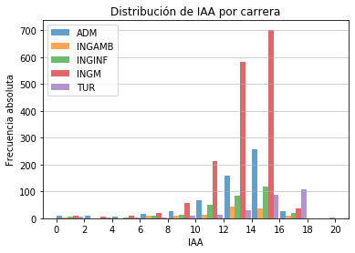

```python
def histograma_iaa(titulo,
                   lista_carreras = carreras.keys(),
                   frec_relativa = False,
                   divisiones = 10,
                   pos_leyenda = 'best'):
    """Grafica un histograma de la distribución de IAA
       de las carreras dadas."""

    # Preparar gráfica
    fig, ax = plt.subplots()
    ax.grid(axis='y', alpha=0.75)
    ax.set_xlabel('IAA')
    if frec_relativa:
        ax.set_ylabel('Frecuencia relativa (%)')
    else:
        ax.set_ylabel('Frecuencia absoluta')
    ax.set_title(titulo)

    # Extraer índices de carreras seleccionadas
    indices_carreras = [iaa[carrera] for carrera in lista_carreras]

    # Preparar ponderaciones para el caso de frecuencia relativa
    porcentajes = [carrera.apply(lambda x: 100.0/carrera.size)
                   for carrera in indices_carreras]

    # Graficar histograma
    n, bins, patches = ax.hist(
        x = indices_carreras,
        bins = divisiones,
        range = (0,20),
        weights = porcentajes if frec_relativa else None,
        rwidth = 0.95,
        alpha = 0.7,
        label = lista_carreras)
    ax.set_xticks(bins)

    # Agregar leyenda y mostrar figura
    ax.legend(loc = pos_leyenda)
    plt.show()

def histograma_carrera(carrera, fr = False):
    """Grafica un histograma de la distribución de IAA
       de una sola carrera."""
    histograma_iaa(carreras[carrera],
                   lista_carreras = [carrera],
                   frec_relativa = fr)


histograma_iaa('Distribución de IAA por carrera',
               pos_leyenda = 'upper left')
```

Como el histograma muestra magnitudes absolutas, lo principal que se nota es la enorme disparidad entre la cantidad de estudiantes de Ingeniería Marítima y el resto de las carreras. Para poder apreciar mejor las diferencias en la distribución de índices académicos usaremos **frecuencias relativas**, es decir, compararemos los porcentajes de estudiantes en cada intervalo de IAA por carrera:

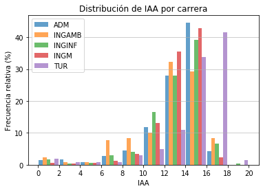

```python
histograma_iaa('Distribución de IAA por carrera',
               frec_relativa = True)
```

Esta gráfica nos permite realizar algunas observaciones preliminares que comprobaremos más adelante:

- Todas las carreras presentan asimetría negativa, es decir, mayor dispersión por debajo del IAA promedio.
- En todas las carreras hay más estudiantes regulares que en probatorio.
- La carrera con la mayor concentración de índices académicos parece ser Licenciatura en Administración.
- El IAA promedio de Licenciatura en Turismo parece ser más alto que el de las demás carreras.
- El IAA promedio de Ingeniería Ambiental parece ser más bajo que el de las demás carras.

Los histogramas anteriores son una manera simple de visualizar la distribución de los índices académicos en intervalos. Sin embargo, la manera en que se dividen los datos puede ofuscar la forma real de la distribución.

Para apreciar mejor la distribución real de los datos, tenemos que hallar una aproximación de su [función de densidad de probabilidad](https://en.wikipedia.org/wiki/Probability_density_function), la cual desconocemos. Una técnica para lograr esto es la llamada [*kernel density estimation (KDE)*](https://en.wikipedia.org/wiki/Kernel_density_estimation) (estimación de densidad del núcleo). En resumen, la técnica consiste en ponderar los datos usando una función positiva llamada *kernel* (núcleo) y un parámetro positivo llamado ancho de banda que determina la *suavidad* de la curva.

La librería Pandas provee una función para graficar la KDE de un conjunto de datos usando una función de núcleo [Gaussiana](https://en.wikipedia.org/wiki/Gaussian_function) y un ancho de banda calculado automáticamente. A continuación se crea y aplica una función para generar este tipo de gráficas para los IAA de las diferentes carreras:

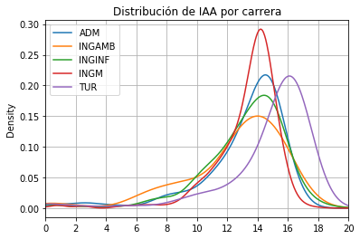

```python
def distribucion_iaa(titulo,
                     lista_carreras = carreras.keys(),
                     promedio = [],
                     mediana = [],
                     moda = []):
    """Grafica la distribución aproximada de IAA
       de las carreras dadas."""

    # Preparar gráfica
    fig, axes = plt.subplots()

    # Extraer índices de carreras seleccionadas
    indices_carreras = df_iaa.filter(items = lista_carreras)

    # Graficar distribución aproximada
    indices_carreras.plot.kde(title = titulo,
                              grid = True,
                              legend = True,
                              xlim = (0, 20),
                              xticks = [2*x for x in range(11)],
                              ax = axes)

    # Graficar medidas de tendencia central de cada carrera
    for carrera in promedio:
        mu = indices_carreras[carrera].mean()
        axes.axvline(mu, color = 'r', linestyle = '--',
                     label = f'{carrera}: μ = {round(mu, 2)}')

    for carrera in mediana:
        md = indices_carreras[carrera].median()
        axes.axvline(md, color = 'g', linestyle = '--',
                     label = f'{carrera}: md = {round(md, 2)}')

    for carrera in moda:
        mo = moda_max(indices_carreras[carrera])
        axes.axvline(mo, color = 'b', linestyle = '--',
                     label = f'{carrera}: mo = {round(mo, 2)}')

    axes.legend()
    plt.show()

def distribucion_carrera(carrera):
    """Grafica la distribución aproximada de IAA
       de una sola carrera."""
    distribucion_iaa(carreras[carrera],
                     lista_carreras = [carrera],
                     promedio = [carrera],
                     mediana = [carrera],
                     moda = [carrera])

distribucion_iaa('Distribución de IAA por carrera')
```

A partir de esta gráfica podemos reiterar y corregir nuestras observaciones preliminares antes de comprobarlas en el análisis por carrera:

- Todas las carreras presentan asimetría negativa, es decir, mayor dispersión por debajo del IAA promedio.
- En todas las carreras hay más estudiantes regulares que en probatorio.
- La carrera con la mayor concentración de índices académicos parece ser Ingeniería Marítima.
- El IAA promedio de Licenciatura en Turismo parece ser más alto que el de las demás carreras.
- El IAA promedio de Ingeniería Ambiental parece ser más bajo que el de las demás carras.

## Licenciatura en Administración (ADM)

Lo primero que hacemos es mostrar una previsualización de la tabla de datos, con los cinco índices académicos más altos y los cinco más bajos:

```python
dfs['ADM'].sort_values(by = 'IAA', ascending = False)
```

| Nro | C.I | Apellidos y Nombres | IAA | Condición |
| --- | --- | --- | --- | --- |
| 362 | 28132377 | MORILLO Samuel | 17.25 | REG |
| 42 | 28305726 | BENITEZ HERRERA Misael Andrés | 17.00 | REG |
| 517 | 25443436 | SOLE LOMBANO Jurannys Del Valle | 16.95 | REG |
| 366 | 15544663 | NARVAEZ BELLORIN Alexander Jose | 16.90 | REG |
| 202 | 20782742 | GONZALEZ NEGRIN Kelwis Lewis | 16.79 | REG |
| ... | ... | ... | ... | ... |
| 191 | 27904889 | GOITIA DELGADO Greimar Alexandra | 0.70 | PRO |
| 200 | 27042909 | GONZALEZ MARTINEZ Luis Sandro | 0.60 | PRO |
| 439 | 27692395 | RANGEL VASQUEZ Yesimar Del Valle | 0.30 | PRO |
| 270 | 28013315 | LEÓN CALDERÓN Jesús Alejandro | 0.15 | PRO |
| 505 | 19914546 | SANTAELLO POLEO Maria Alejandra | 0.00 | PRO |

574 rows × 4 columns

Segundo, una breve descripción estadística de esta tabla:

```python
describir_carrera('ADM')
```

|  | ADM |
| --- | --- |
| count | 574.00 |
| contar_reg | 441.00 |
| contar_pro | 133.00 |
| porcentaje_reg | 76.83 |
| porcentaje_pro | 23.17 |
| max | 17.25 |
| min | 0.00 |
| mean | 13.06 |
| median | 13.98 |
| moda_max | 15.07 |
| std | 2.99 |
| kurt | 4.94 |
| skew | -2.06 |

Luego, un histograma del número de estudiantes por IAA en diez subintervalos:

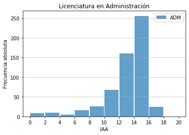

```python
histograma_carrera('ADM')
```

Por último, la distribución aproximada de los IAA y sus medidas de tendencia central:

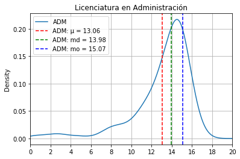

```python
distribucion_carrera('ADM')
```

## Ingeniería Ambiental (INGAMB)

Lo primero que hacemos es mostrar una previsualización de la tabla de datos, con los cinco índices académicos más altos y los cinco más bajos:

```python
dfs['INGAMB'].sort_values(by = 'IAA', ascending = False)
```

| Nro | C.I | Apellidos y Nombres | IAA | Condición |
| --- | --- | --- | --- | --- |
| 25 | 20562293 | DURAN ROBLES Gian Carlos | 17.63 | REG |
| 83 | 26217878 | PATRIZ VILLEGAS Jenifer Adriana | 16.80 | REG |
| 28 | 27882088 | ESPINA BRUCE Dainella Josbeth | 16.60 | REG |
| 70 | 25915097 | MENDOZA BENITEZ Oriana Coromoto | 16.48 | REG |
| 114 | 26465658 | SANTAELLA NAVARRO Jennifer Beatriz | 16.47 | REG |
| ... | ... | ... | ... | ... |
| 40 | 28184374 | GONCALVES GABRIEL Hamil Gabriel | 5.35 | PRO |
| 42 | 30170198 | GONZALEZ MARTINEZ Katerin Alexandra | 2.15 | PRO |
| 50 | 28313974 | GUILLEN LOZANO Brencelys Nazareth | 0.30 | PRO |
| 110 | 27487439 | SALCEDO MONASTERIO Jean Franco Daniel | 0.24 | PRO |
| 73 | 29743729 | MONTILLA GARCIA Ramses Jesus | 0.00 | PRO |

130 rows × 4 columns

Segundo, una breve descripción estadística de esta tabla:

```python
describir_carrera('INGAMB')
```

|  | INGAMB |
| --- | --- |
| count | 130.00 |
| contar_reg | 91.00 |
| contar_pro | 39.00 |
| porcentaje_reg | 70.00 |
| porcentaje_pro | 30.00 |
| max | 17.63 |
| min | 0.00 |
| mean | 12.48 |
| median | 13.20 |
| moda_max | 14.21 |
| std | 3.41 |
| kurt | 2.81 |
| skew | -1.54 |

Luego, un histograma del número de estudiantes por IAA en diez subintervalos:

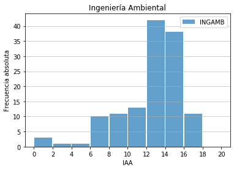

```python
histograma_carrera('INGAMB')
```

Por último, la distribución aproximada de los IAA y sus medidas de tendencia central:

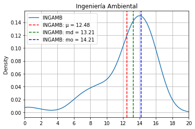

```python
distribucion_carrera('INGAMB')
```

## Ingeniería Informática (INGINF)

Lo primero que hacemos es mostrar una previsualización de la tabla de datos, con los cinco índices académicos más altos y los cinco más bajos:

```python
dfs['INGINF'].sort_values(by = 'IAA', ascending = False)
```

| Nro | C.I | Apellidos y Nombres | IAA | Condición |
| --- | --- | --- | --- | --- |
| 180 | 27225685 | OCHOA PALACIO Samuel David | 18.89 | REG |
| 296 | 27042926 | VILCHEZ DOMINGUEZ Omar Enrique | 17.97 | REG |
| 144 | 29777971 | MARTÍNEZ CABRERA Oriana Estefania | 17.95 | REG |
| 191 | 28132505 | OVALLES VERA Liz Aneth | 17.23 | REG |
| 63 | 25561417 | DI LORENZO VÉLEZ Enrique Gabriel | 17.22 | REG |
| ... | ... | ... | ... | ... |
| 301 | 28013843 | YURDEN RADA Yondri José | 1.95 | PRO |
| 223 | 31291035 | RAMIREZ CARTAYA Ivan Dario | 0.10 | PRO |
| 201 | 26647800 | PARRA UGUETO Ulices Francisco | 0.10 | PRO |
| 250 | 27441618 | ROMERO MARCANO Anotnio Jose | 0.10 | PRO |
| 23 | 28305410 | BOLIVAR CONTRERAS Jose Alberto | 0.10 | PRO |

304 rows × 4 columns

Segundo, una breve descripción estadística de esta tabla:

```python
describir_carrera('INGINF')
```

|  | INGINF |
| --- | --- |
| count | 304.00 |
| contar_reg | 225.00 |
| contar_pro | 79.00 |
| porcentaje_reg | 74.01 |
| porcentaje_pro | 25.99 |
| max | 18.89 |
| min | 0.10 |
| mean | 13.08 |
| median | 13.73 |
| moda_max | 15.34 |
| std | 2.87 |
| kurt | 5.38 |
| skew | -1.85 |

Luego, un histograma del número de estudiantes por IAA en diez subintervalos:

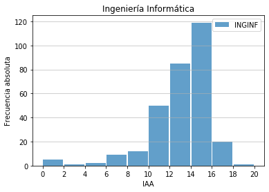

```python
histograma_carrera('INGINF')
```

Por último, la distribución aproximada de los IAA y sus medidas de tendencia central:

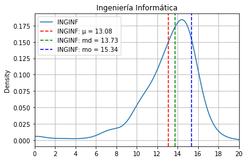

```python
distribucion_carrera('INGINF')
```

## Ingeniería Marítima (INGM)

Lo primero que hacemos es mostrar una previsualización de la tabla de datos, con los cinco índices académicos más altos y los cinco más bajos:

```python
dfs['INGM'].sort_values(by = 'IAA', ascending = False)
```

| Nro | C.I | Apellidos y Nombres | IAA | Condición |
| --- | --- | --- | --- | --- |
| 910 | 28052786 | MASTROMATTEO Domingo Antonio | 18.28 | REG |
| 737 | 28496411 | KHAWAM BATMAN Christian Jesus | 17.87 | REG |
| 779 | 26994119 | LINARES RIVAS Osmel Adonis | 17.42 | REG |
| 395 | 26885643 | DÍAZ PIÑA Isaac José | 17.33 | REG |
| 1331 | 27663773 | ROMERO GOMEZ Jesus Alexis | 17.21 | REG |
| ... | ... | ... | ... | ... |
| 1346 | 27693451 | RUIZ CANO Keneddy Joseph | 0.75 | PRO |
| 446 | 28340776 | FERMÍN VELÁSQUEZ Clay Miguel | 0.52 | PRO |
| 353 | 27858946 | DARIAS OJEDA Marco Antonio | 0.52 | PRO |
| 482 | 28076241 | GALLARDO GARCÍA Angel David | 0.52 | PRO |
| 1072 | 27079410 | PACHECO CABELLO Reivielis Coromoto | 0.00 | REG |

1639 rows × 4 columns

Segundo, una breve descripción estadística de esta tabla:

```python
describir_carrera('INGM')
```

|  | INGM |
| --- | --- |
| count | 1639.00 |
| contar_reg | 1322.00 |
| contar_pro | 317.00 |
| porcentaje_reg | 80.66 |
| porcentaje_pro | 19.34 |
| max | 18.28 |
| min | 0.00 |
| mean | 13.28 |
| median | 13.83 |
| moda_max | 14.17 |
| std | 2.23 |
| kurt | 8.74 |
| skew | -2.34 |

Luego, un histograma del número de estudiantes por IAA en diez subintervalos:

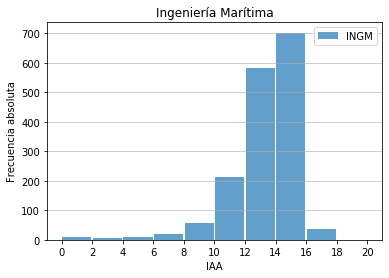

```python
histograma_carrera('INGM')
```

Por último, la distribución aproximada de los IAA y sus medidas de tendencia central:

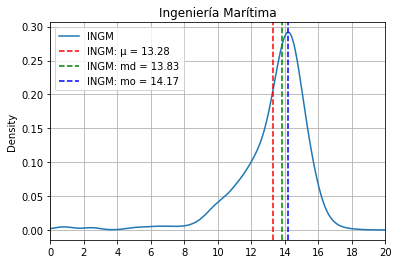

```python
distribucion_carrera('INGM')
```

## Licenciatura en Turismo (TUR)

Lo primero que hacemos es mostrar una previsualización de la tabla de datos, con los cinco índices académicos más altos y los cinco más bajos:

```python
dfs['TUR'].sort_values(by = 'IAA', ascending = False)
```

| Nro | C.I | Apellidos y Nombres | IAA | Condición |
| --- | --- | --- | --- | --- |
| 199 | 25575357 | RODRIGUEZ MENESES Krimildha Anabella Shereshade | 18.30 | REG |
| 22 | 26180738 | BLEQUETT VERNA María Laura | 18.11 | REG |
| 33 | 13044740 | CAMPOS RODRIGUEZ Carmen Lourdes | 18.08 | REG |
| 61 | 24272643 | DELGADO GONZÁLEZ Yrene Karina | 18.06 | REG |
| 256 | 28149706 | VENTURA DIAZ Gabriela Anais | 17.98 | REG |
| ... | ... | ... | ... | ... |
| 151 | 29973267 | MONTILLA PEREZ Mariel Patricia | 1.13 | PRO |
| 173 | 30022605 | PEÑA RODRIGUEZ Osgrey Ayari | 0.35 | PRO |
| 178 | 27774408 | PEREZ MARTINEZ Yorbis Jesus | 0.00 | PRO |
| 175 | 28184655 | PERES DIAZ Jekcsylina Yamali | 0.00 | PRO |
| 165 | 27859374 | OROPEZA SANDREA Eliany Daniela | 0.00 | PRO |

263 rows × 4 columns

Segundo, una breve descripción estadística de esta tabla:

```python
describir_carrera('TUR')
```

|  | TUR |
| --- | --- |
| count | 263.00 |
| contar_reg | 231.00 |
| contar_pro | 32.00 |
| porcentaje_reg | 87.83 |
| porcentaje_pro | 12.17 |
| max | 18.30 |
| min | 0.00 |
| mean | 14.72 |
| median | 15.71 |
| moda_max | 16.70 |
| std | 3.23 |
| kurt | 7.66 |
| skew | -2.56 |

Luego, un histograma del número de estudiantes por IAA en diez subintervalos:

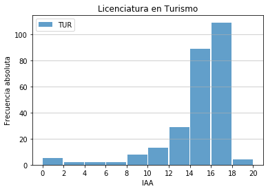

```python
histograma_carrera('TUR')
```

Por último, la distribución aproximada de los IAA y sus medidas de tendencia central:

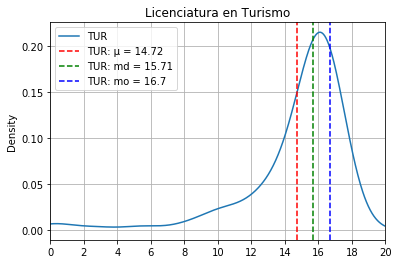

```python
distribucion_carrera('TUR')
```

## Comparación de datos, interpretación y conclusiones

A continuación se presentan la distribución aproximada de los IAA por carrera (de nuevo) y una tabla con la descripción estadística de cada carrera:

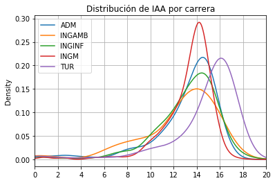

```python
distribucion_iaa('Distribución de IAA por carrera')
```

```python
describir_iaa(df_iaa)
```

|  | ADM | INGAMB | INGINF | INGM | TUR |
| --- | --- | --- | --- | --- | --- |
| count | 574.00 | 130.00 | 304.00 | 1639.00 | 263.00 |
| contar_reg | 441.00 | 91.00 | 225.00 | 1322.00 | 231.00 |
| contar_pro | 133.00 | 39.00 | 79.00 | 317.00 | 32.00 |
| porcentaje_reg | 76.83 | 70.00 | 74.01 | 80.66 | 87.83 |
| porcentaje_pro | 23.17 | 30.00 | 25.99 | 19.34 | 12.17 |
| max | 17.25 | 17.63 | 18.89 | 18.28 | 18.30 |
| min | 0.00 | 0.00 | 0.10 | 0.00 | 0.00 |
| mean | 13.06 | 12.48 | 13.08 | 13.28 | 14.72 |
| median | 13.98 | 13.20 | 13.73 | 13.83 | 15.71 |
| moda_max | 15.07 | 14.21 | 15.34 | 14.17 | 16.70 |
| std | 2.99 | 3.41 | 2.87 | 2.23 | 3.23 |
| kurt | 4.94 | 2.81 | 5.38 | 8.74 | 7.66 |
| skew | -2.06 | -1.54 | -1.85 | -2.34 | -2.56 |